# integration

2023-10-08

Three different strategies of approximating the integral:

$$\int_B f d \mathbf{P}$$
1. Sample from $\mathbf{P}$. Take averages: $\sum_{i=1}^{N} \frac{f(x_i)}{N}$ ($=\int_B f d\hat{F}$).

Suppose $f$ is Riemann integrable *and* $\mathbf{P}$ has a density $g$ w.r.t Lebesgue Measure

2. you could now repeat 1. but with measure $\mu$ and you would get $_{i=1}^{N} f(x_i)g(x_i) $ (the samples are now going to be uniform in $B$)
3. you could this integral is $\int_B f(x)g(x) d\mu(x)$ by straightforward Riemann integral definition:
- Partitioning the range into $N$ equal $\delta$-intervals: $\delta_i = [l_i; r_i), r_i - l_i = \delta$
- Compute the integral sum: $\sum_{i=1}^{N} {f(l_i)} \delta$. If the length of $B$ is K, then this becomes $\sum_{i=1}^{N} {f(l_i)g(l_i)} \frac{K}{N}$
- Those integral sums are guaranteed to converge in this case (by definition).

This what makes LLN so great – you can approximate the integral without knowing $\mathbb{P}$ or, equivalently, $g$.

Besides, even if you do know the distribution, you can still use this theorem to calculate integrals more easily. For example, if you wanted to know $P(\mathcal{N}(0,1) \le t) = \Phi(t)$, you could sample from Normal and compute $f(x)=I_{\{x \le t\}}$. This can be used, for example, when you need to estimate thresholds for hypothesis testing, or p-values of observed data.

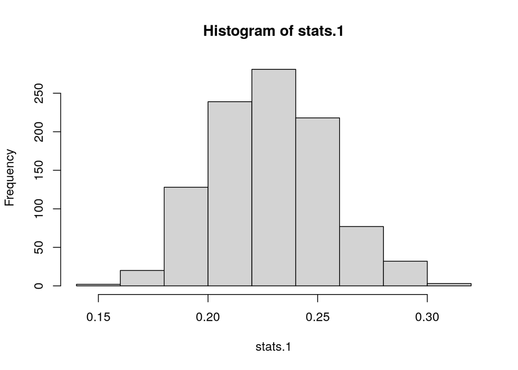

```r
# 1.
stats.1 = c()
for (i in 1:1000) {
  lower = -1
  upper = 2
  snorm = rnorm(1000)
  rs = snorm[(snorm > lower) & (snorm < upper)]
  stats.1 = append(stats.1, mean(rs))
}
hist(stats.1)
```

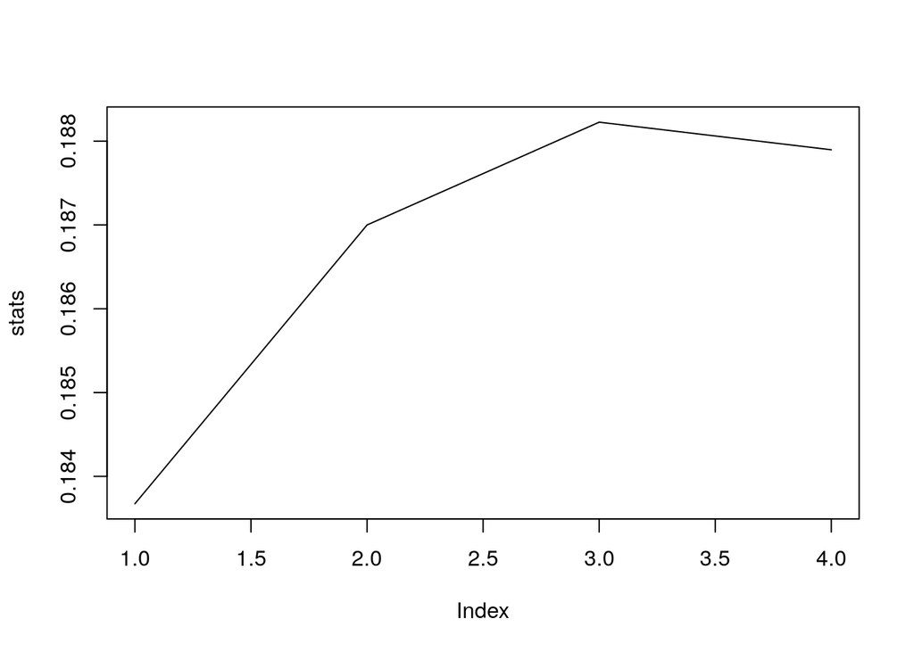

```r
require(plotrix)
# 2.
stats = c()
for (n_samples in c(10, 100, 1000, 10000)) {
  stat_i = c()
  for (i in 1:1000) {
    lower = -1
    upper = 2
    K = upper - lower
    unis = runif(n_samples, min=lower, max=upper)
    stat_i = append(stat_i, K * mean(unis*dnorm(unis)))
  }
  stats = append(stats, mean(stat_i))
}
plot(stats, type='l')
```

```r
# 3.
lower = -1
upper = 2
K = upper - lower
N = 10000
range = seq(lower, upper, length.out=N)
# dx * x * f(x)
sum(K/N * range * dnorm(range))
```

```
## [1] 0.1879409
```